# boxplot_excise

Sanghoo Yoon

### 상자그림

- ggplot2 패키지 안의 diamonds 자료를 불러와 그림을 그리고자 한다.

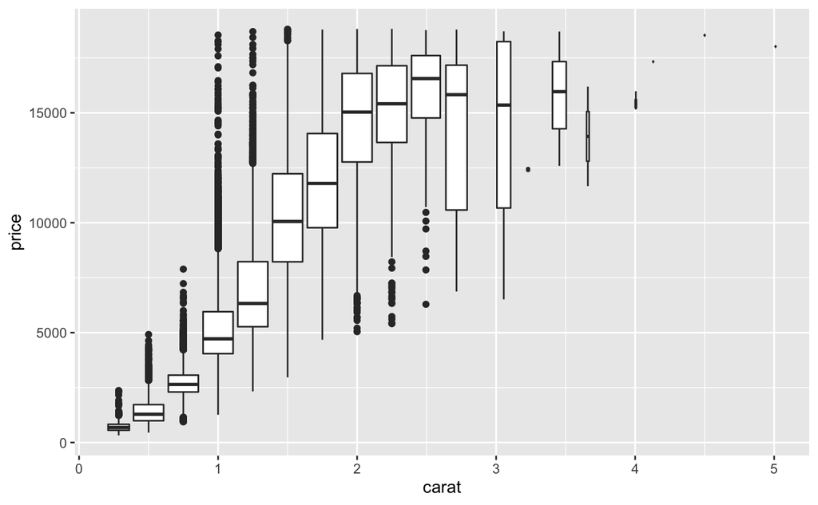

- 위의 그림을 그리기 위해선 아래의 작업이 필요하다.
- 먼저 cut을 이용하여 carat을 0.25단위로 쪼개야 한다.
- 이후 쪼개진 단위로 그림을 그리면 그림이 그려진다.
- outline=F 옵션을 주면 이상치는 제외된다.

```r
library(ggplot2)
data(diamonds)
head(diamonds)
```

```
## # A tibble: 6 x 10
##   carat cut       color clarity depth table price     x     y     z
##   <dbl> <ord>     <ord> <ord>   <dbl> <dbl> <int> <dbl> <dbl> <dbl>
## 1 0.23  Ideal     E     SI2      61.5    55   326  3.95  3.98  2.43
## 2 0.21  Premium   E     SI1      59.8    61   326  3.89  3.84  2.31
## 3 0.23  Good      E     VS1      56.9    65   327  4.05  4.07  2.31
## 4 0.290 Premium   I     VS2      62.4    58   334  4.2   4.23  2.63
## 5 0.31  Good      J     SI2      63.3    58   335  4.34  4.35  2.75
## 6 0.24  Very Good J     VVS2     62.8    57   336  3.94  3.96  2.48
```

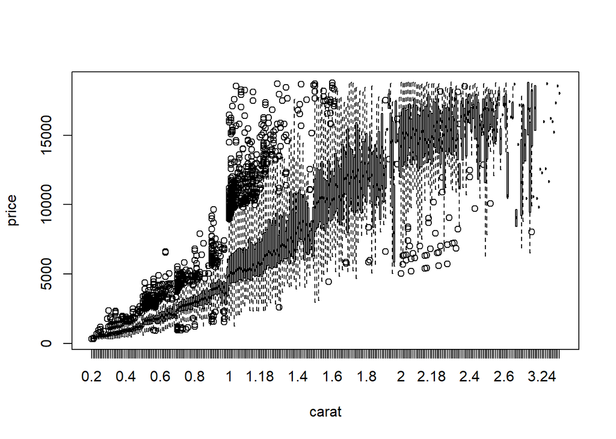

```r
boxplot(price~carat, data=diamonds)
```

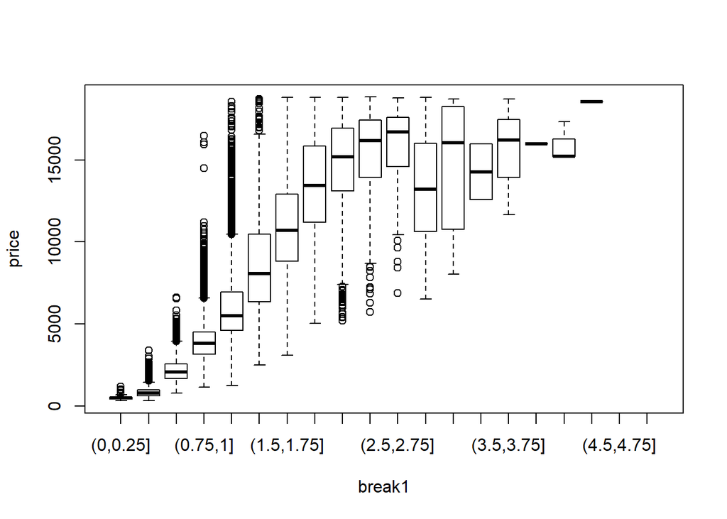

```r
breaks1<-cut(diamonds$carat,seq(0,5,0.25))
diamonds$break1 <- breaks1

boxplot(price~break1, data=diamonds)
```

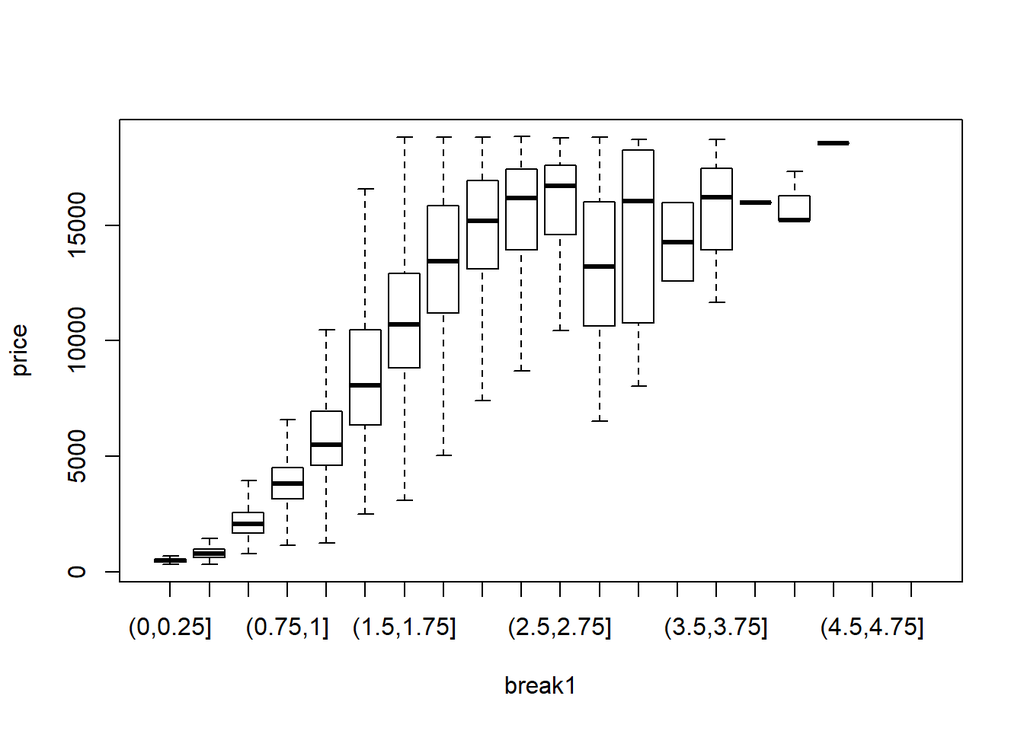

```r
boxplot(price~break1, data=diamonds, outline=F)
```

- 수업자료에 없지만 이상치를 빨간색으로 그릴 수 있습니다. (outlier, color, boxplot, in r)
- 위의 그림에서 이상치를 빨간색 원으로 표현해보세요.

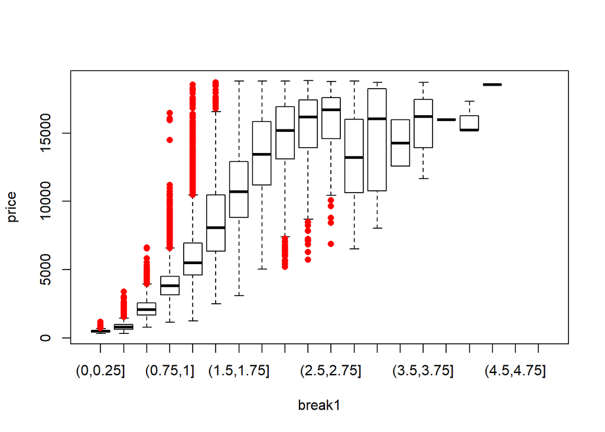

뉴욕에서 관측된 대기오염물질에 관련된 자료입니다.

월별 오존농도가 궁금한 경우 아래의 그림을 그릴 수 있습니다.

```r
data(airquality)
head(airquality)
```

```
##   Ozone Solar.R Wind Temp Month Day
## 1    41     190  7.4   67     5   1
## 2    36     118  8.0   72     5   2
## 3    12     149 12.6   74     5   3
## 4    18     313 11.5   62     5   4
## 5    NA      NA 14.3   56     5   5
## 6    28      NA 14.9   66     5   6
```

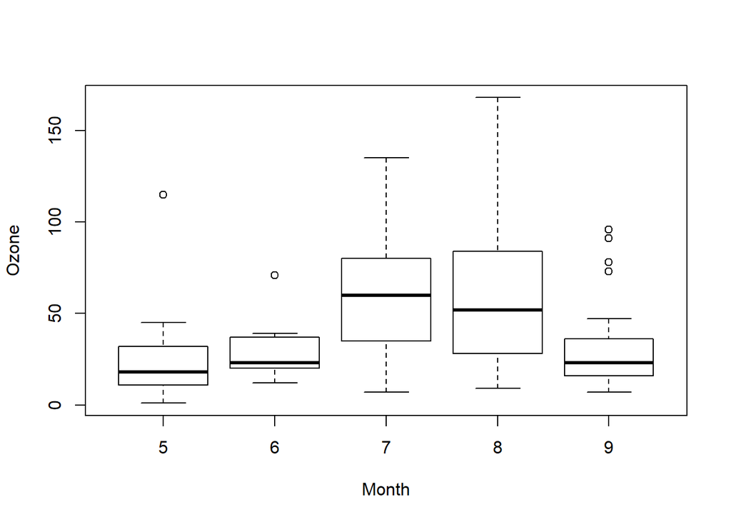

```r
boxplot(Ozone~Month, data=airquality)
```